# IIIT Vadodara

## Winter 2021-22

## CS 612, CS 652, CS/IT 308 Machine Learning

## Lab#5 Basic optimization techniques

# Dharmraj Rathod

202061008 Mtech CSE Machine_Learning_LAB-5

```python
%matplotlib inline
import numpy as np
import matplotlib.pyplot as plt
from scipy import misc
from scipy.io import wavfile
from numpy import linalg as la
import matplotlib.image as mpimg
import glob
from numpy import linalg as LA
import scipy.io as sio
```

**Problem 1)** Find minima of following functions using gradient descent method with learning rate 0.01 and 0.1 along with different number of iterations. Try choosing a large value of learning rate and test the convergence. Plot the functions, highlight corresponding minima, and show convergence/divergence on the plot.

(a) $L_1(θ) = θ^2$

(b) $L_2(θ) = θ_1^2 + θ_2^2$

(c) $L_3(θ) = (θ - 1)^2$

(d) $L_4(θ) = 2 (θ_1-1)^2 + 2(θ_2-1)^2$

```
3.847852167616652e-06
125
```

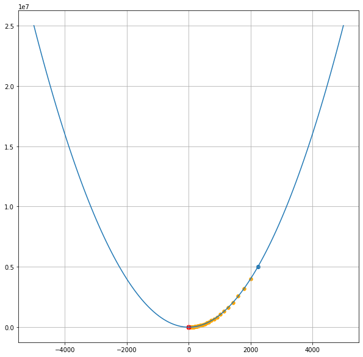

```python
import numpy as np
import pandas as pd
import matplotlib.pyplot as plt
from mpl_toolkits.mplot3d import Axes3D
import statistics as st
import sympy as sy
import math



def l1_wrt_theta(theta_val):
    return (2*theta_val)
def l2_wrt_theta(theta):
    return (2*theta)
def l3_wrt_theta(theta):
    return (2*(theta-1))
def l4_wrt_theta(theta):
    return (4*(theta-1))

# you can assume
# theta=5000000
# p=theta+1
# e=0.000001
# alpha=0.1
# count = 0
# theta_values = []
# itr = []


# can use while loop for |p-theta|>e
def convergence(alpha):
    theta=5000000
    p=theta+1
    e=0.000001
    x = np.linspace(-5000,5000,125)
    y = x**2
    plt.plot(x,y)
    x1 = 5000000
    y1 = math.sqrt(x1)
    plt.scatter(y1,x1)
    count = 0
    theta_values = []
    itr = []
    while(abs(p-theta) > e):
        p = theta
        theta = theta - alpha*(l1_wrt_theta(theta))
        count +=1
        theta_values.append(theta)
        itr.append(count)
    yfin = []
    for i in theta_values:
        yfin.append(math.sqrt(i))

#plot the function and convergence

    plt.scatter(yfin,theta_values,color='orange',s=30)
    plt.scatter(yfin[len(yfin)-1],theta_values[len(theta_values)-1],color='red',s=50)
    plt.gcf().set_size_inches((10, 10))
    plt.grid()
#     print(theta_values)
#     print(itr)
    print(theta)
    print(count)



convergence(0.1)
```

```
4.871862228969798e-05
1255
```

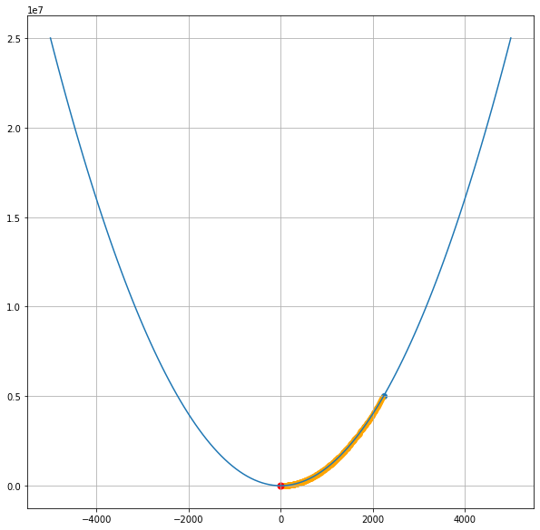

```python
convergence(0.01)
```

Q1 (b)

```
6.67495948725285e-07 3.3374797436264246e-06
105
```

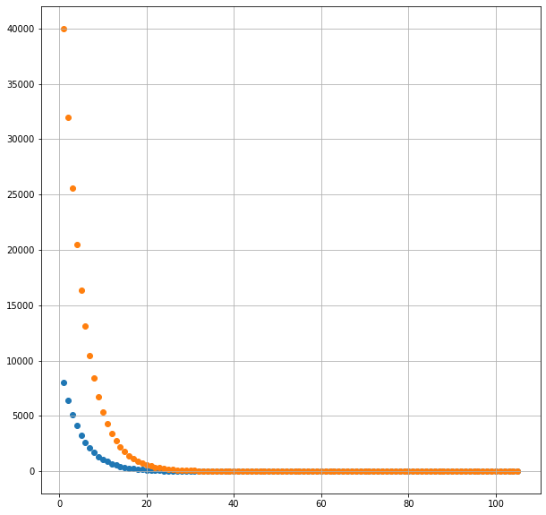

```python
def convergence2(alpha):
    theta0=10000
    theta1=50000
    p0=theta0+1
    p1=theta1+1
    e=0.000001

    count = 0
    theta_values0 = []
    theta_values1 = []
    itr = []




    while((abs(p0-theta0) > e) or (abs(p1-theta1) > e)):
        p0 = theta0
        p1 = theta1
        theta0 = theta0 - alpha*(l2_wrt_theta(theta0))
        theta1 = theta1 - alpha*(l2_wrt_theta(theta1))
        count +=1
        theta_values0.append(theta0)
        theta_values1.append(theta1)
        itr.append(count)

    print(theta0,theta1)
    print(count)
    plt.scatter(itr,theta_values0)
    plt.scatter(itr,theta_values1)
    plt.gcf().set_size_inches((10, 10))
    plt.grid()

convergence2(0.1)
```

```
9.753932283676505e-06 4.876966141838254e-05
1027
```

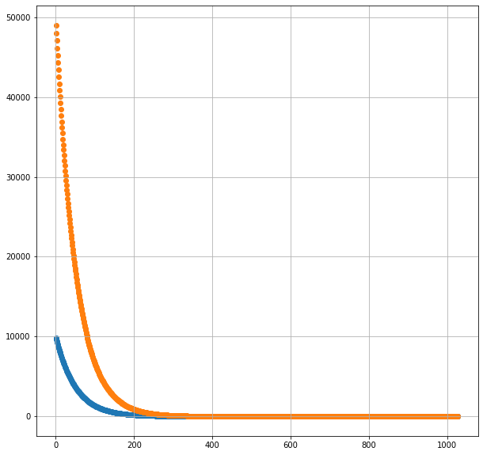

```python
#theta0=10000
#theta1=50000

#e=0.000001
#alpha=0.1

# can use while loop for |theta0-p0|>e or |theta1-p1|>e:


convergence2(0.01)

# print(theta0,theta1)
# print(cnt)
```

Q1 (c)

```
1.0000033025934667
74
```

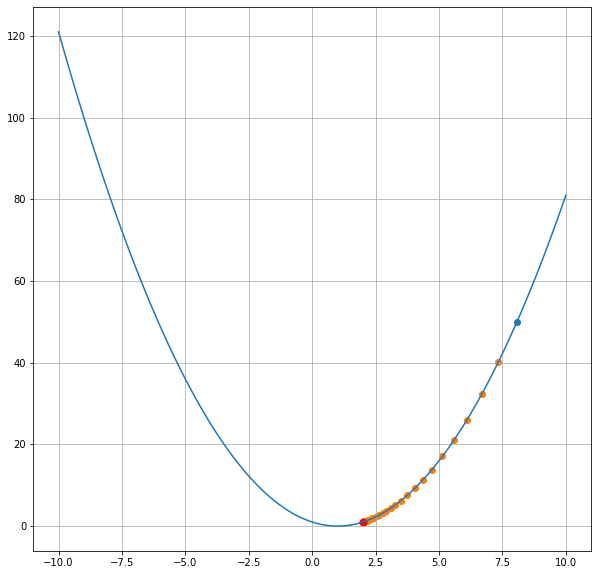

```python
def l3_wrt_theta(theta):
    return (2*(theta-1))

def convergence3(alpha):
    theta=50
    p=theta+1
    e=0.000001
    x = np.linspace(-10,10,100)
    y = (x-1)**2

    plt.plot(x,y)
    x1 = 50
    y1 = math.sqrt(x1)+1
    plt.scatter(y1,x1)
    count = 0
    theta_values = []
    itr = []



    while(abs(p-theta) > e):
        p = theta
        theta = theta - alpha*(l3_wrt_theta(theta))
        count +=1
        theta_values.append(theta)
        itr.append(count)
    yfin = []
    for i in theta_values:
        yfin.append(math.sqrt(i)+1)

#plot the function and convergence
#     y = (x-1)**2
    plt.scatter(yfin,theta_values)
    plt.scatter(yfin[len(yfin)-1],theta_values[len(theta_values)-1],color='red',s=50)
    plt.gcf().set_size_inches((10, 10))
    plt.grid()
#     print(theta_values)
#     print(itr)
    print(theta)
    print(count)


convergence3(0.1)
```

```
1.0000488463203852
684
```

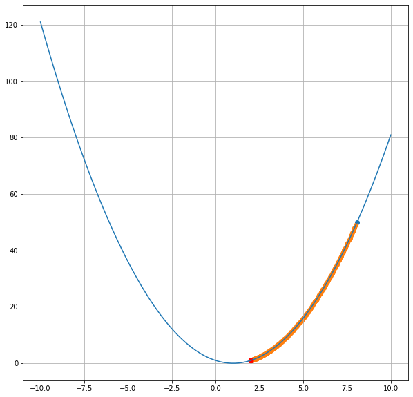

```python
# theta0=50
# p=theta0+1
# e=0.000001
# alpha=0.1

# while for |theta0-p|>e:



convergence3(0.01)
# print(theta0)
# print(cnt)
```

Q1 (d)

```
1.0000002245001247 1.000001122590433
48
```

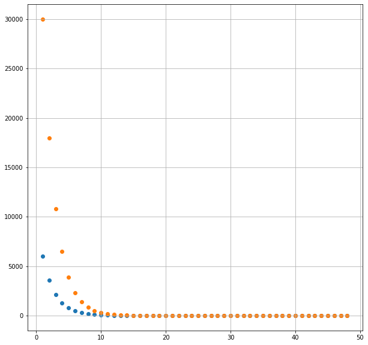

```python
def l4_wrt_theta(theta):
    return (4*(theta-1))


def convergence4(alpha):
    theta0=10000
    theta1=50000
    p0=theta0+1
    p1=theta1+1
    e=0.000001

    count = 0
    theta_values0 = []
    theta_values1 = []
    itr = []




    while((abs(theta0-p0) > e) or (abs(theta1-p1) > e)):
        p0 = theta0
        p1 = theta1
        theta0 = theta0 - alpha*(l4_wrt_theta(theta0))
        theta1 = theta1 - alpha*(l4_wrt_theta(theta1))
        count +=1
        theta_values0.append(theta0)
        theta_values1.append(theta1)
        itr.append(count)

    print(theta0,theta1)
    print(count)
    plt.scatter(itr,theta_values0)
    plt.scatter(itr,theta_values1)
    plt.gcf().set_size_inches((10, 10))
    plt.grid()

convergence4(0.1)
```

```
1.0000047274304387 1.0000236390433557
526
```

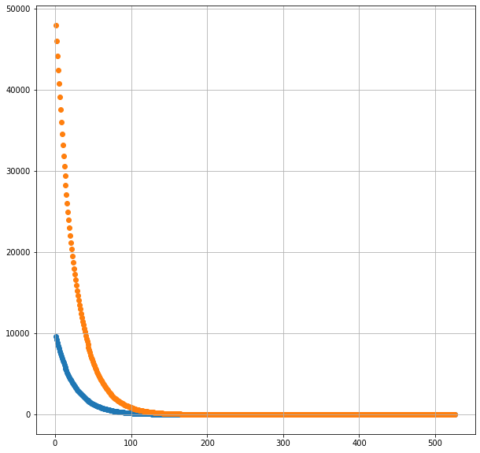

```python
#theta0=10000
#theta1=50000


#e=0.000001
#alpha=0.1

#while loop for |theta0-p0|>e or |theta1-p1|>e:



convergence4(0.01)

# print(theta0,theta1)
# print(cnt)
```

**Problem 2)** Consider $A=\begin{bmatrix} 0.7 & 0.2\\ 0.1 & 0.6 \end{bmatrix}$ and the observation matrix $b=\begin{bmatrix} 0.5\\ 0.6 \end{bmatrix}$ in a system $Ax=b$. However, $b$ is not in column space of $A$, thus $Ax \neq b$ and we need to find $x$ in such a way that $Ax \approx b$. Using linear least square $x$ can be estimated by minimizing the mean squared error as, $\min ||Ax-b||_2$.

This can be written as,

$\underset{x}{\mathrm{argmin}}||Ax-b||_{2}^{2} = f(x)$

We need to find $x$ in such a way that $f(x)$ will be minimum in $L_2$ norm.

You need to solve this least square problem using gradient descent algortithm on $f(x)$.

To apply this algorithm we need to find gradient of the function, i.e.,  
$\Delta_x f(x)= A^T(Ax-b) = A^TAx-A^Tb$

Optimisation for least-squares  
$||A^TAx-A^Tb||_2>\delta$, $\delta$ is the small positive number indicating tolerance.

Now we will find new $x$ iteratively using step size $\alpha$ to find the best fit for $AX=b$ as:

$x^{[n+1]}=x^{[n]}-\alpha (A^TAx-A^Tb)$.

We need to choose $\alpha$, $\delta$ and $x^{[0]}$ to iterate until $x^{[n+1]} \rightarrow x^{[n]}$.

```python
#Write your code here.
A = np.array(np.mat('0.7 0.2 ;0.1 0.6'))
b = np.array(np.mat('0.5 ; 0.6'))

# alpha = 0.01
# delta = 0.0000001

def gradient_fx(x):
    AT = np.transpose(A)
    A1 = AT.dot(A)
    X1 = A1.dot(x)
    X2 = AT.dot(b)
    return (X1-X2)

def converge_minima(delta,alpha):
    x = np.array(np.mat('2 ; 2'))
    x0 = x+1
    xvalues = []
    counts = []
    count = 0
    while(((x0[0]-x[0]) > delta) or ((x0[1]-x[1]) > delta) ):
        x0 = x
        x = x - alpha*(gradient_fx(x))
        count += 1
        xvalues.append(x)
        counts.append(count)
    print("Iteration = ",count)
    print("Solution = \n",x)
    print("Varify how much is it converging : = \n",A.dot(x))

converge_minima(0.0000001,0.1)
converge_minima(0.0000001,0.01)


converge_minima(0.00001,0.1)
converge_minima(0.00001,0.01)


converge_minima(0.0001,0.1)
converge_minima(0.0001,0.01)
```

```
Iteration =  394
Solution =
 [[0.45000391]
 [0.92499499]]
Varify how much is it converging : =
 [[0.50000174]
 [0.59999738]]
Iteration =  3023
Solution =
 [[0.45004088]
 [0.92494764]]
Varify how much is it converging : =
 [[0.50001815]
 [0.59997267]]
Iteration =  207
Solution =
 [[0.45039698]
 [0.92449398]]
Varify how much is it converging : =
 [[0.50017668]
 [0.59973608]]
Iteration =  1256
Solution =
 [[0.45343606]
 [0.92138405]]
Varify how much is it converging : =
 [[0.50168205]
 [0.59817404]]
Iteration =  124
Solution =
 [[0.45340016]
 [0.92132268]]
Varify how much is it converging : =
 [[0.50164465]
 [0.59813362]]
Iteration =  743
Solution =
 [[0.47184079]
 [0.92001404]]
Varify how much is it converging : =
 [[0.51429136]
 [0.5991925 ]]
```

**Problem 3)** Apply stochastic gradient algorithm on the given dataset and estimate $\theta_0$, $\theta_1$ and final cost value. Step by step hints have been given for the same.

```python
import numpy as np
import matplotlib.pyplot as plt
%matplotlib inline
```

```python
plt.style.use(['ggplot'])
```

1) Dataset:

```python
X = 2 * np.random.rand(100,1)
y = 4 + 3 * X + np.random.randn(100,1)
```

2) Visualize the data.

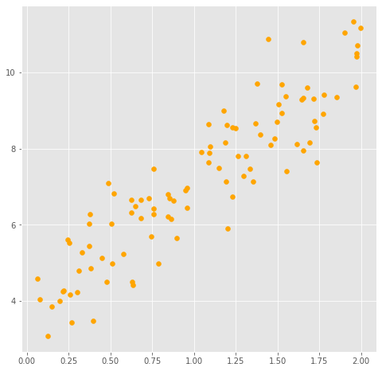

```python
plt.scatter(X,y,color='orange')
plt.gcf().set_size_inches((8, 8))
```

3) We will write the line equation $y=m \space x+c$ in machine learning form as $J(\theta)=\theta_1 X + \theta_0$. Now choose one random sample $X_b$ (you can concatenate ones and $X$) and find $\theta_{best} = (X_b^T X_b)^{-1}X_b^Ty$.

```python
#Write code here.
#X_b
#theta_best
X_b = []
for i in X:
    X_b.append([1,i[0]])

X_bT = np.transpose(X_b)
inverse = np.linalg.inv(X_bT.dot(X_b))
rightpart = X_bT.dot(y)
theta_best = inverse.dot(rightpart)

# print(theta_best)



print(theta_best)
```

```
[[3.80467492]
 [3.26862195]]
```

4) For example choose $X_{new}=\begin{bmatrix} 0 \\ 2 \end{bmatrix}$. Obtain $X_{new_b}$ by concatinating ones and $X_{new}$. Finally find $y_{predict}=X_{new_b}\theta_{best}$.

```python
#Write code here.
#X_new
X_new = np.array(np.mat('0;2'))
# X_new = [0 2]

#X_new_b
X_new_b = []
for i in X_new:
    X_new_b.append([1,i[0]])
# print(X_new_b)
X_new_b = np.transpose(np.transpose(X_new_b))


#y_predict
y_predict = X_new_b.dot(theta_best)


print(y_predict)
```

```
[[ 3.80467492]
 [10.34191883]]
```

5) Visualize $X_{new}$ and $y_{predict}$.

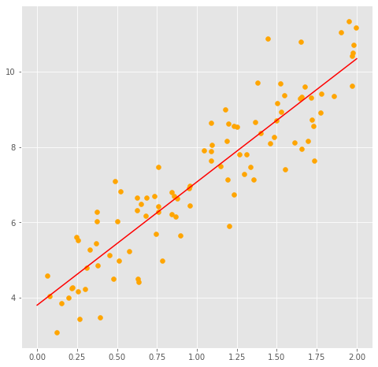

```python
plt.scatter(X,y,color='orange')
plt.plot(X_new,y_predict,"red")
plt.gcf().set_size_inches((8, 8))
```

6) Define the cost function.

```python
def  cal_cost(theta,X,y):

    m = len(y)

    predictions = X.dot(theta)
    cost = (1/2*m) * np.sum(np.square(predictions-y))

    return cost
```

7) Define the gradient descent function.

```python
def gradient_descent(X,y,theta,learning_rate=0.01,iterations=100):

    m = len(y)
    cost_history = np.zeros(iterations)
    theta_history = np.zeros((iterations,2))
    for it in range(iterations):
        prediction = np.dot(X,theta)
        theta = theta -(1/m)*learning_rate*( X.T.dot((prediction - y)))
        theta_history[it,:] =theta.T
        cost_history[it]  = cal_cost(theta,X,y)

    return theta, cost_history, theta_history
```

8) Using learning rate $0.01$ and $1000$ iterations find $\theta_0$, $\theta_1$ and final cost.

```python
lr =0.01
n_iter = 1000

theta = np.random.randn(2,1)

X_b = np.c_[np.ones((len(X),1)),X]

theta,cost_history,theta_history = gradient_descent(X_b,y,theta,lr,n_iter)


print('Theta0:          {:0.3f},\nTheta1:          {:0.3f}'.format(theta[0][0],theta[1][0]))
print('Final cost/MSE:  {:0.3f}'.format(cost_history[-1]))
```

```
Theta0:          3.980,
Theta1:          3.007
Final cost/MSE:  4736.595
```

```python
lr =0.01
n_iter = 1000

theta = np.random.randn(2,1)

X_b = np.c_[np.ones((len(X),1)),X]

theta,cost_history,theta_history = gradient_descent(X_b,y,theta,lr,n_iter)


print('Theta0:          {:0.3f},\nTheta1:          {:0.3f}'.format(theta[0][0],theta[1][0]))
print('Final cost/MSE:  {:0.3f}'.format(cost_history[-1]))
```

```
Theta0:          4.251,
Theta1:          2.766
Final cost/MSE:  4684.736
```

9) Plot $J(\theta)$ and iterations.

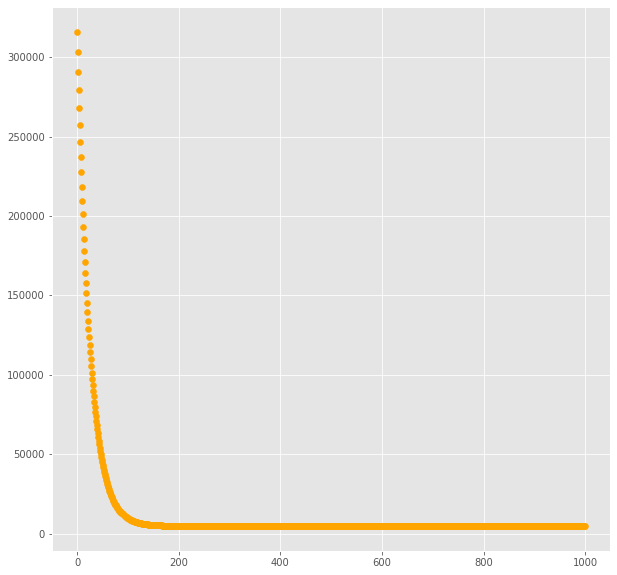

```python
iterw = []
for i in range(n_iter):
    iterw.append(i)

plt.scatter(iterw,cost_history,color='orange')
plt.gcf().set_size_inches((10, 10))
```

10) You can also observe the changes in cost function.

```python
import numpy as np
import pandas as pd
import matplotlib.pyplot as plt
from mpl_toolkits.mplot3d import Axes3D
import statistics as st
import sympy as sy
# from google.colab import files
# uploaded = files.upload()
```

```
94
[23.71808511 -6.90381606]
```

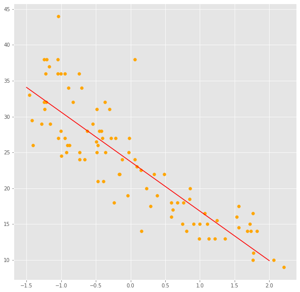

```python
data = pd.read_csv('data.csv')
x = data['x']
y = data['y']
print(len(y))
x = (x - x.mean()) / x.std()
plt.scatter(x,y,color = "orange")

X_b1 = []
for i in x:
    X_b1.append([1,i])


X_b1T = np.transpose(X_b1)
inverse = np.linalg.inv(X_b1T.dot(X_b1))
rightpart = X_b1T.dot(y)
theta_best = inverse.dot(rightpart)


X_new = np.array(np.mat('-1.5;2'))
X_new_b = []
for i in X_new:
    X_new_b.append([1,i[0]])
# print(X_new_b)
X_new_b = np.transpose(np.transpose(X_new_b))


#y_predict
y_predict = X_new_b.dot(theta_best)



plt.plot(X_new,y_predict,"red")
plt.gcf().set_size_inches((10, 10))

print(theta_best)
```

```python
def  cal_cost(theta,X,y):
    m = len(y)
    predictions = X.dot(theta)
    cost = (1/2*m) * np.sum(np.square(predictions-y))
    return cost

def gradient_descent1(X,y,theta,learning_rate=0.01,eps = 1e-7):
    m = len(y)
    theta = theta + 1
    cost_history = []
    theta_history = []
    counts = []
    count = 0
    p1 = theta[0] + 1
    p2 = theta[1] + 1

    while ((abs(p1-theta[0]) > eps) or (abs(p2-theta[1]) > eps)):
        p1 = theta[0]
        p2 = theta[1]
        prediction = np.dot(X,theta)
        theta = theta -(1/m)*learning_rate*( X.T.dot((prediction - y)))
        theta_history.append(theta.T)
        cost_history.append(cal_cost(theta,X,y))
        counts.append(cal_cost(theta,X,y))
        count +=1
    print(count)

    return theta, cost_history, theta_history,counts
```

```python
alpha =0.01
# n_iter = 1000
eps = 1e-7

theta = np.array(np.mat('1000;500'))
X = []
Y = []
for i in range(len(x)):
    X.append([x[i]])
    Y.append([y[i]])

X_b = np.c_[np.ones((len(X),1)),X]

theta,cost_history,theta_history = gradient_descent1(X_b,Y,theta,alpha,eps)
print(theta)
```

[output not shown]

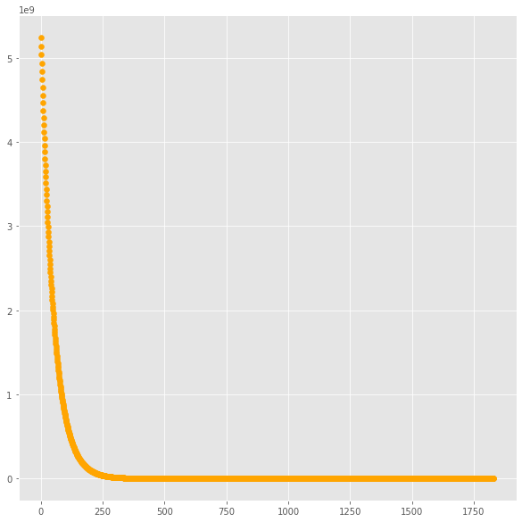

```python
iterw = []
for i in range(len(cost_history)):
    iterw.append(i)

plt.scatter(iterw,cost_history,color='orange')
plt.gcf().set_size_inches((10, 10))
```

```python
alpha =0.1
eps = 1e-6

theta = np.array(np.mat('1000;500'))
X = []
Y = []
for i in range(len(x)):
    X.append([x[i]])
    Y.append([y[i]])

X_b = np.c_[np.ones((len(X),1)),X]

theta,cost_history,theta_history = gradient_descent1(X_b,Y,theta,alpha,eps)
print(theta)
```

[output not shown]

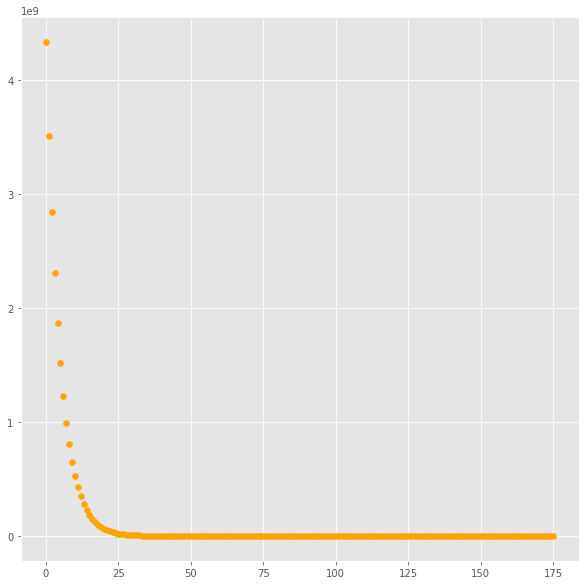

```python
iterw = []
for i in range(len(cost_history)):
    iterw.append(i)

plt.scatter(iterw,cost_history,color='orange')
plt.gcf().set_size_inches((10, 10))
```